# Analyzing Gaming Company Sales and Impact from 1978 to 2016

**By Jessica Nah and Sam Chen**

[figure not shown]

## Introduction

```python
# These are the Python libraries that will help us to accomplish our data analysis
# for storing the dataset into a Pandas dataframe and completing data analysis and visualization

import pandas as pd
import matplotlib.pyplot as plt
import numpy as np

# The following sklearn libraries will help us to create polynomial regression models of best fit
# when we want to see what the sales for games released in future years look
# like for Nintendo, Microsoft, Sony, and PC
from sklearn.linear_model import LinearRegression
from sklearn.metrics import r2_score
from sklearn.preprocessing import PolynomialFeatures
```

## Data Collection/Curation

In order to begin our exploration of this question regarding change/growth in the video game industry, we selected datasets that have already been curated online. A dataset curated by Abdulshaheed Alqunber contained the data we were looking for regarding individual video game titles with their sales numbers, ratings, and identifying information.

**Dataset:** https://www.kaggle.com/ashaheedq/video-games-sales-2019  
The dataset curated by Abdulshaheed Alqunber was found on kaggle.com and can be downloaded as a .csv file (vgsales-12-4-2019.csv). The dataset contains entries with the name of the video game, the platform on which the game runs, year the video game was released, ESRB maturity rating, publisher and developer of the game, genre of the game, and the number of sales (in millions) across various regions like North America, Europe, and Japan as well as total global sales. It also imported the critic score and user score for the game when those values were available (generated from reviews on Metacritic.com).

It was interesting to note that, after taking a quick look at the data from both datasets, one piece of data that we are extremely interested in is the number of sales for a particular game. However, there are columns that seem to be exclusive to one another. The Global_Sales, NA_Sales, PAL_Sales, JP_Sales, and Other_Sales would only have a number if Total_Shipped was NaN. The inverse was true as well; if Total_Shipped had a numerical value, then the Global_Sales, NA_Sales, PAL_Sales, JP_Sales, and Other_Sales would be missing. After observing this, we figured that these columns are exclusive to one another, and that they actually give the same information we're looking for but in different columns. It is possible that the data itself on vgchartz was formatted in a way that had "Global_Sales" or "Total_Shipped," one or the other but never both. Thus, this observation will help us to deal with the missing values in a simpler way later on.

```python
# Read in the dataset  using Pandas read_csv() function, converts vgsales-12-4-2019.csv into a Pandas dataframe;
# we inspect the size just to have an idea of the amount of data we're working with.
games = pd.read_csv('vgsales-12-4-2019.csv')
len(games)
```

```
55792
```

```python
# Inspect df to make sure it matches the csv dataset we imported and that everything looks correct
games.head()
```

|  | Rank | Name | basename | Genre | ESRB_Rating | Platform | Publisher | Developer | VGChartz_Score | Critic_Score | ... | NA_Sales | PAL_Sales | JP_Sales | Other_Sales | Year | Last_Update | url | status | Vgchartzscore | img_url |
| --- | --- | --- | --- | --- | --- | --- | --- | --- | --- | --- | --- | --- | --- | --- | --- | --- | --- | --- | --- | --- | --- |
| 0 | 1 | Wii Sports | wii-sports | Sports | E | Wii | Nintendo | Nintendo EAD | NaN | 7.7 | ... | NaN | NaN | NaN | NaN | 2006.0 | NaN | http://www.vgchartz.com/game/2667/wii-sports/?... | 1 | NaN | /games/boxart/full_2258645AmericaFrontccc.jpg |
| 1 | 2 | Super Mario Bros. | super-mario-bros | Platform | NaN | NES | Nintendo | Nintendo EAD | NaN | 10.0 | ... | NaN | NaN | NaN | NaN | 1985.0 | NaN | http://www.vgchartz.com/game/6455/super-mario-... | 1 | NaN | /games/boxart/8972270ccc.jpg |
| 2 | 3 | Mario Kart Wii | mario-kart-wii | Racing | E | Wii | Nintendo | Nintendo EAD | NaN | 8.2 | ... | NaN | NaN | NaN | NaN | 2008.0 | 11th Apr 18 | http://www.vgchartz.com/game/6968/mario-kart-w... | 1 | 8.7 | /games/boxart/full_8932480AmericaFrontccc.jpg |
| 3 | 4 | PlayerUnknown's Battlegrounds | playerunknowns-battlegrounds | Shooter | NaN | PC | PUBG Corporation | PUBG Corporation | NaN | NaN | ... | NaN | NaN | NaN | NaN | 2017.0 | 13th Nov 18 | http://www.vgchartz.com/game/215988/playerunkn... | 1 | NaN | /games/boxart/full_8052843AmericaFrontccc.jpg |
| 4 | 5 | Wii Sports Resort | wii-sports-resort | Sports | E | Wii | Nintendo | Nintendo EAD | NaN | 8.0 | ... | NaN | NaN | NaN | NaN | 2009.0 | NaN | http://www.vgchartz.com/game/24656/wii-sports-... | 1 | 8.8 | /games/boxart/full_7295041AmericaFrontccc.jpg |

5 rows × 23 columns

## Data Management and Representation

After getting the data, the next part of the data science pipeline is data management and representation. While the data is conveniently located all within one dataframe, such that we do not have to join or merge two separate Pandas dataframes together, we certainly need to "refine" the dataset. Data management and representation in our case primarily means keeping the necessary data columns that we would be using and dropping the unnecessary columns; we also would want to manage missing data properly and drop any entries that are not meaningful. In this case, regarding missing data, we must act upon our initial observation, and change the sales values (millions) so that it is all correctly contained within one column (Global_Sales column should be transferred to Total_Shipped column if Total_Shipped is missing). We are also looking to remove entries that are included in the dataset but have little information contained for the entry (sales, publisher, developer, year, etc).

```python
# We know immediately that there are certain columns that can and should be dropped. VGChartz_Score seems to be
# both extremely subjective as well as often missing for most video games. The basename is pretty similar
# to the actual name of the game, and we would only need the regular video game title for identification purposes.
# The rank is nice to show which titles have been the highest selling throughout history, but we also prefer not
# to use this for the analysis (we find it more practical to analyze success from the number of sales for a
# video game title rather than analyzing success from its historical rank in best-selling games).

# Finally, last_update, url, status, Vgchartzscore, and img_url seem cool, but not particularly useful for any analysis.
games = games.drop(['Rank', 'basename', 'VGChartz_Score', \
                    'Last_Update', 'url', 'status', 'Vgchartzscore', 'img_url'], axis=1)
```

```python
# Inspect the dataframe after dropping unnecessary columns to see what the data looks like.
games.head()
```

|  | Name | Genre | ESRB_Rating | Platform | Publisher | Developer | Critic_Score | User_Score | Total_Shipped | Global_Sales | NA_Sales | PAL_Sales | JP_Sales | Other_Sales | Year |
| --- | --- | --- | --- | --- | --- | --- | --- | --- | --- | --- | --- | --- | --- | --- | --- |
| 0 | Wii Sports | Sports | E | Wii | Nintendo | Nintendo EAD | 7.7 | NaN | 82.86 | NaN | NaN | NaN | NaN | NaN | 2006.0 |
| 1 | Super Mario Bros. | Platform | NaN | NES | Nintendo | Nintendo EAD | 10.0 | NaN | 40.24 | NaN | NaN | NaN | NaN | NaN | 1985.0 |
| 2 | Mario Kart Wii | Racing | E | Wii | Nintendo | Nintendo EAD | 8.2 | 9.1 | 37.14 | NaN | NaN | NaN | NaN | NaN | 2008.0 |
| 3 | PlayerUnknown's Battlegrounds | Shooter | NaN | PC | PUBG Corporation | PUBG Corporation | NaN | NaN | 36.60 | NaN | NaN | NaN | NaN | NaN | 2017.0 |
| 4 | Wii Sports Resort | Sports | E | Wii | Nintendo | Nintendo EAD | 8.0 | 8.8 | 33.09 | NaN | NaN | NaN | NaN | NaN | 2009.0 |

```python
# For each row, we inspect its 'Total_Shipped' column to see if data is missing (which most likely means the data
# we're looking for is located in the 'Global_Sales' column). To be sure, we cross-referenced multiple rows with
# the sales data from the website itself, Google, and other datasets to make sure that Global_Sales was the
# equivalent and correct number to Total_Shipped, and those numbers should've just been in the same column.
# Global_Sales also happened to be the exact sum of the values for NA_Sales, PAL_Sales, JP_Sales, and Other_Sales.
for index, row in games.iterrows():
    if np.isnan(row['Total_Shipped']):
        games.at[index, 'Total_Shipped'] = row['Global_Sales']
```

By this point, the Total_Shipped columns if they were missing before should now be filled with correct numerical values taken from the Global_Sales column. If there are any np.NaN values left, it means that no sales data at all was available in the dataset from either column. Regardless, we should be able to drop Global_Sales (and with so many values missing, NA_Sales, PAL_Sales, JP_Sales, and Other_Sales can be dropped because a regional analysis would require a dataset with less missing information for those columns).

```python
games.head()
```

|  | Name | Genre | ESRB_Rating | Platform | Publisher | Developer | Critic_Score | User_Score | Total_Shipped | Global_Sales | NA_Sales | PAL_Sales | JP_Sales | Other_Sales | Year |
| --- | --- | --- | --- | --- | --- | --- | --- | --- | --- | --- | --- | --- | --- | --- | --- |
| 0 | Wii Sports | Sports | E | Wii | Nintendo | Nintendo EAD | 7.7 | NaN | 82.86 | NaN | NaN | NaN | NaN | NaN | 2006.0 |
| 1 | Super Mario Bros. | Platform | NaN | NES | Nintendo | Nintendo EAD | 10.0 | NaN | 40.24 | NaN | NaN | NaN | NaN | NaN | 1985.0 |
| 2 | Mario Kart Wii | Racing | E | Wii | Nintendo | Nintendo EAD | 8.2 | 9.1 | 37.14 | NaN | NaN | NaN | NaN | NaN | 2008.0 |
| 3 | PlayerUnknown's Battlegrounds | Shooter | NaN | PC | PUBG Corporation | PUBG Corporation | NaN | NaN | 36.60 | NaN | NaN | NaN | NaN | NaN | 2017.0 |
| 4 | Wii Sports Resort | Sports | E | Wii | Nintendo | Nintendo EAD | 8.0 | 8.8 | 33.09 | NaN | NaN | NaN | NaN | NaN | 2009.0 |

```python
# Drop the aforementioned columns because they are no longer needed
games = games.drop(['Global_Sales', 'NA_Sales', 'PAL_Sales', 'JP_Sales', 'Other_Sales'], axis=1)
```

```python
# Just to convert the column type to the correct data type, we change the 'Year' column values
# from a float type to an int type
games = games.astype({'Year': 'Int64'})
```

```python
# Reorganizing the columns in the order we prefer to look at them; name, genre, and year
# make sense to appear first in order because those are the primary means of identifying the game
games = games[['Name', 'Genre', 'Year','Total_Shipped', 'ESRB_Rating', 'Platform', 'Publisher', 'Developer', 'Critic_Score', 'User_Score']]
```

```python
games.head()
```

|  | Name | Genre | Year | Total_Shipped | ESRB_Rating | Platform | Publisher | Developer | Critic_Score | User_Score |
| --- | --- | --- | --- | --- | --- | --- | --- | --- | --- | --- |
| 0 | Wii Sports | Sports | 2006 | 82.86 | E | Wii | Nintendo | Nintendo EAD | 7.7 | NaN |
| 1 | Super Mario Bros. | Platform | 1985 | 40.24 | NaN | NES | Nintendo | Nintendo EAD | 10.0 | NaN |
| 2 | Mario Kart Wii | Racing | 2008 | 37.14 | E | Wii | Nintendo | Nintendo EAD | 8.2 | 9.1 |
| 3 | PlayerUnknown's Battlegrounds | Shooter | 2017 | 36.60 | NaN | PC | PUBG Corporation | PUBG Corporation | NaN | NaN |
| 4 | Wii Sports Resort | Sports | 2009 | 33.09 | E | Wii | Nintendo | Nintendo EAD | 8.0 | 8.8 |

```python
len(games)
```

```
55792
```

It's worth it at this point to examine the number of missing values for each column in the dataset. It's more than possible for there to be a lot of missing values, as the website that was scraped does not seem reliable enough to have filled-in values for every video game entry out of 55,792 video games.

```python
# check number of missing values in games dataframe
missing = pd.DataFrame(games.isna().sum(),columns=["# of Missing Values"])
missing
```

|  | # of Missing Values |
| --- | --- |
| Name | 0 |
| Genre | 0 |
| Year | 979 |
| Total_Shipped | 34550 |
| ESRB_Rating | 32169 |
| Platform | 0 |
| Publisher | 0 |
| Developer | 17 |
| Critic_Score | 49256 |
| User_Score | 55457 |

Sure enough, we can see that a significant number of entries have missing values pertaining to number of copies shipped, ESRB_Rating, Critic_Score, and User_Score. Regarding rating, critic score, and user score, we may have some need for those column values should they exist, but it would be impossible to know what those values should be if they're missing (and we cannot impute the values for the missing data from other column values). However, if Total_Shipped is missing, this would greatly affect what we seek to analyze. It makes the most sense to ignore those columns and limit our population to the video games where the data for sales is available. Therefore, we create a new dataframe that has this specific population: Video games where the sales are available in the Total_Shipped column. The original 'games' still can be used to keep track of overall video game titles without sales, but if we're looking for video games with sales numbers available, we should use the resulting 'df2' created below.

```python
# df2 now becomes the rows of 'games' dataframe where the Total_Shipped column values were not np.NaN (missing)
df2 = games[games['Total_Shipped'].notnull()].copy()
len(df2)
```

```
21242
```

```python
# check that new dataframe does not have any missing values in "Total Shipped" column
missing = pd.DataFrame(df2.isna().sum(),columns=["# of Missing Values"])
missing
```

|  | # of Missing Values |
| --- | --- |
| Name | 0 |
| Genre | 0 |
| Year | 38 |
| Total_Shipped | 0 |
| ESRB_Rating | 6604 |
| Platform | 0 |
| Publisher | 0 |
| Developer | 4 |
| Critic_Score | 16381 |
| User_Score | 21000 |

We've now inspected the missing values in the new dataframe, and we're okay with the missing data that's left for rating, critic scores, and user scores. We surely have to take into consideration these missing values if we want to use those columns for analysis, but for now, we're content knowing the name, genre, year, platform, publisher, and developer of a specific game. Next, we want to determine the timeline of our data, so we group the dataframe by year and chart the number of games published in each year to get a general understanding of the data.

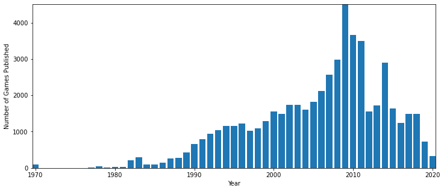

```python
years = games.groupby("Year")
yrg = dict()

# create dictionary with year as key and total published games as the value
for g in list(years.groups.keys()):
    yrg[g] = len(years.get_group(g))

# visualize number of games published per year as bar chart
plt.bar(*zip(*yrg.items()))
plt.xlabel("Year")
plt.ylabel("Number of Games Published")
plt.show()
```

As for the ending cutoff point, although the video game dataset does accurately include games released until 2020, it wouldn't be ideal to keep our analysis going until 2020. VGChartz is not a reliable site for updating sales immediately; thus, recent games from the past few years have much, much lower sales recorded in the dataset than in reality. For example, God of War from 2018 has 6.15 million sales according to the dataset. However, the title is one of the best-selling games ever on the PS4; it sold over 10 million units in just over a year, and was recently estimated to have surpassed 20 million copies sold.

In order to circumvent our charts from being extremely inaccurate, we chose to arbitrarily demonstrate the video game industry's growth and sales until 2016, which was a reasonable gap from 2021 for VGChartz to have accurate sales information. We did cross-reference video game sales from 2016 to make sure it was more or less accurate for historical sales numbers and not a vast underestimate. Otherwise, we probably would have seen a shocking drop of sales beyond 2016 (and we surely did), to the point of suggesting that the video game industry is about to crash and die, and that is also clearly a false conclusion.

```python
games.loc[games['Year'] == 1970].head()
```

[output not shown]

```python
games.loc[games['Name'] == 'God of War (2018)'].head()
```

[output not shown]

```python
# For both dataframes, I drop any rows for video game titles released in years before 1978 and after 2016
games = games[games["Year"] < 2017].reset_index(drop=True)
games = games[games["Year"] > 1977].reset_index(drop=True)
df2 = df2[df2["Year"] < 2017].reset_index(drop=True)
df2 = df2[df2["Year"] > 1977].reset_index(drop=True)
df2.head()
```

[output not shown]

## Exploratory Data Analysis

How has the video game industry grown over time and what does it look like now? Over the past forty years, the gaming industry has grown through new companies, new games, new consoles, and new players. In order to answer our big question, we need to determine a way to measure the growth of the video game industry.

As you can see, there are many categorical and numerical data columns available for us to use in our analysis. Part of the data science process is really understanding which of these columns are useful for the questions we want to ask; furthermore, when we "poke around" the dataset to see what it contains, we can inform and "revise" the questions we want to ask. In other words, which questions are even appropriate to ask with the data we're given? For example, how useful is it to perform an analysis of user score or critic score? It seemed like there were a lot of missing data values regarding the Metacritic ratings, so something that seemed possibly useful at the start might not actually be practical to analyze.

As seen in our bar chart above, the number of published games peaked around 2008 - 2009, and seems to be decreasing since. However, we already know that gaming is not on the decline. With the changing format of games, it may be that published games have only decreased because the playability and lifetime of games have increased. Therefore, simply looking at the number of published games is not a good metric for measuring the growth of the industry.

To measure the growth of the gaming industry, we decided to look at the success of the game companies through the games they published. We gathered a list of all the game publishers mentioned in our dataset and placed them in a dictionary, corresponding to the number of games they published.

```python
# group dataset by publisher
pub = df2.groupby("Publisher")
```

```python
print(len(pub))
```

```
894
```

```python
pubg = dict()
# for each publisher, add publisher to dictionary with number of associated games
for g in list(pub.groups.keys()):
    pubg[g] = len(pub.get_group(g))
```

```python
# print dictionary, starting with companies with the most published games
for w in sorted(pubg, key=pubg.get, reverse=True):
    if(pubg[w] > 500):
        print(w, pubg[w])
```

```
Activision 1032
Ubisoft 980
Electronic Arts 836
Konami 785
THQ 742
Nintendo 707
Sega 690
Sony Computer Entertainment 645
Unknown 610
EA Sports 526
```

However, the number of publishers and their associated games were far too many to be usefully analyzed and visualized. So we turned our attention to the game companies behind the gaming platforms.

Game consoles are an important source of revenue for game companies such as Microsoft, Sony, and Nintendo. A game must be played through some sort of platform after all, and in more recent years, subscriptions and the ability to download purchased games instead of inserting a physical copy have made the profitability of game consoles even more apparent. As such, we decided to create a new column in our dataframe to list the console developer of the game's platform.

```python
plat = games.groupby("Platform")
p = dict()
for g in list(plat.groups.keys()):
    p[g] = len(plat.get_group(g))

for w in sorted(p, key=p.get, reverse=True):
    print(w, p[w])
```

```
PC 9761
PS2 3551
DS 3246
PS 2702
XBL 2092
PSN 1972
PS3 1803
PSP 1781
GBA 1647
X360 1641
Wii 1630
GB 1592
SNES 1206
NES 1097
3DS 1079
XB 977
And 961
GEN 800
PSV 794
DSiW 745
SAT 738
PS4 716
GC 662
DC 653
VC 652
OSX 586
2600 484
PCE 459
WW 454
XOne 441
N64 393
WiiU 359
GG 334
MS 333
3DO 304
Linux 303
SCD 217
WS 199
NG 171
Int 125
```

[output cut: 19 more lines]

```
ZXS 19
AST 17
GBC 17
iQue 15
MSX 7
CDi 6
NS 6
ApII 4
FMT 3
S32X 3
TG16 3
CD32 2
Aco 1
BBCM 1
C128 1
```

```python
# check all consoles mentioned in data
uniq = df2['Platform'].unique()
uniq
```

```
array(['Wii', 'NES', 'GB', 'DS', 'PC', 'X360', 'SNES', 'PS3', 'PS4',
       '3DS', 'PS2', 'GBA', 'GEN', 'N64', 'PS', 'XOne', 'WiiU', 'XB',
       'PSP', '2600', 'GC', 'GBC', 'PSN', 'PSV', 'DC', 'SAT', 'SCD', 'WS',
       'XBL', 'VC', 'NG', 'WW', 'PCE', '3DO', 'GG', 'OSX', 'PCFX', 'Mob'],
      dtype=object)
```

There are a smaller amount of platforms listed in our data. We decided to narrow down the platforms we looked at to the ones with at least 67 games published on that platform (otherwise, there would be too many minor platforms that barely made a difference and were not tied to any of the major platform companies like Nintendo, SEGA, or Atari). Through the helpful use of Google, we associated each platform with a company and created the aforementioned column in our dataframe. We placed those platforms into the dictionary tied to a certain "Console Developer," the company that developed the console.

```python
# create dictionary where each console “key” corresponds to its developer “value”
consoleCompany = {}

consoleCompany.update(dict.fromkeys(['Wii', 'NES', 'GB', 'DS', 'GBA', 'SNES', \
'3DS', 'GC', 'WiiU', 'N64', 'NS','VC','WW','DSiW','DSi'], 'Nintendo'))
consoleCompany.update(dict.fromkeys(['GG', 'GEN', 'SCD', 'DC', 'SAT','MS'], 'SEGA'))
consoleCompany.update(dict.fromkeys(['PS', 'PSP', 'PS2', 'PS3', 'PS4', 'PSV', 'PSN'], 'Sony'))
consoleCompany.update(dict.fromkeys(['PC','OSX','Linux'], 'PC'))
consoleCompany.update(dict.fromkeys(['PCFX', 'PCE'], 'NEC'))
consoleCompany.update(dict.fromkeys(['WS'], 'Bandai'))
consoleCompany.update(dict.fromkeys(['NG'], 'SNK Corporation'))
consoleCompany.update(dict.fromkeys(['2600','Lynx','5200','7800','AJ'], 'Atari'))
consoleCompany.update(dict.fromkeys(['3DO'], '3DO Company'))
consoleCompany.update(dict.fromkeys(['And'], 'Android'))
consoleCompany.update(dict.fromkeys(['XB', 'X360', 'XOne','XBL'], 'Microsoft'))
consoleCompany.update(dict.fromkeys(['Int'], 'Mattel'))
```

```python
# add corresponding developer to each major console
for a,b in df2.iterrows():
    if b['Platform'] in consoleCompany:
        df2.loc[a, "Console Developer"] = consoleCompany[b["Platform"]]
    else:
        df2.loc[a, "Console Developer"] = np.nan
```

```python
for a,b in games.iterrows():
    if b['Platform'] in consoleCompany:
        games.loc[a, "Console Developer"] = consoleCompany[b["Platform"]]
    else:
        games.loc[a, "Console Developer"] = np.nan
```

To help us visualize the data, we created graphs for each notable console developer, with the total historical number of sales made through games published on that console in a given year, tracking the sales through the years 1978 to 2016.

At this point, we would like to make clear that in our data, the number of sales for each game is not how many games were sold that year, but the overall game sales since the game was published in that year. However, the sales still speak to the game’s popularity and success at the time of publishing. It is more likely for a game to have a high amount of sales in the year it was published, with a less significant number of sales the following years. Therefore, we will view the sales listed with each game as representative of the number of sales made the year it was published with this disclaimer in mind.

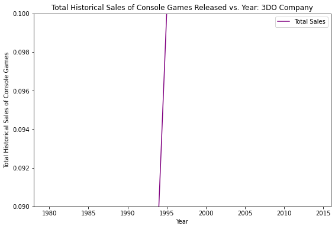

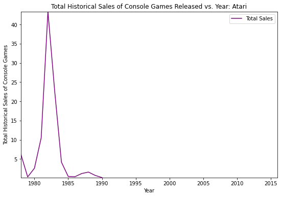

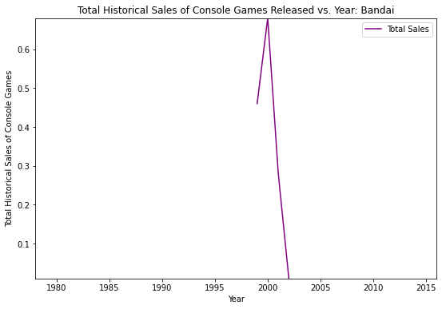

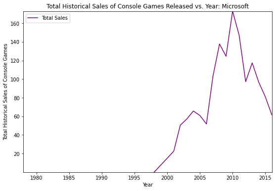

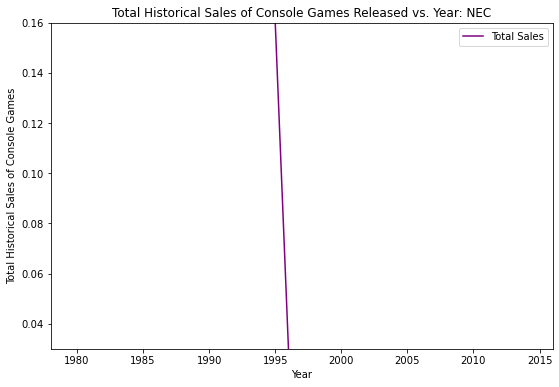

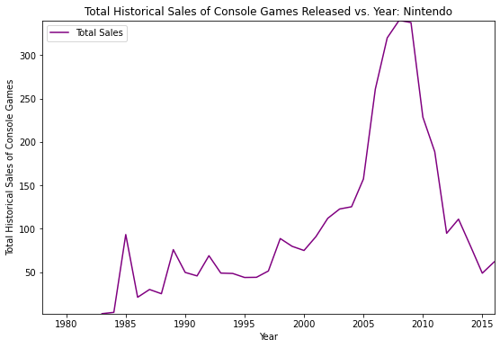

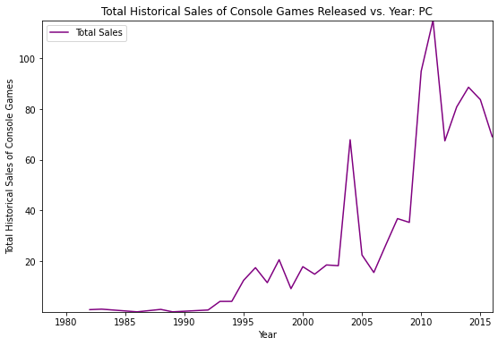

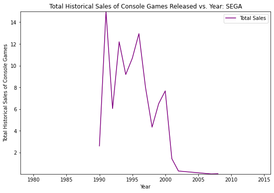

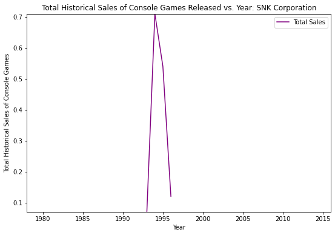

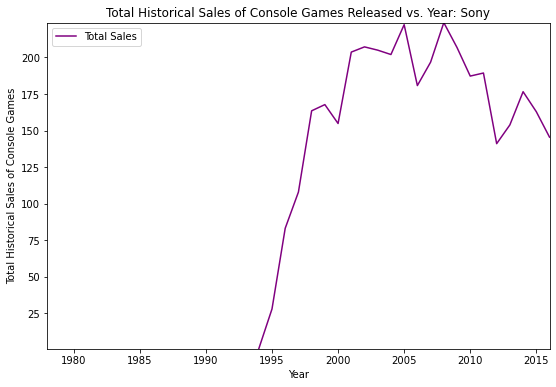

```python
# for each console developer, create a graph of total game sales per year
for label, group in df2.groupby(['Console Developer']):

    # create new dataframe to help plot sales
    consoleDF = pd.DataFrame(columns = ['Total Sales', 'Year'])

    # add row of each year's total sales into dataframe
    for k, g in group.groupby(['Year']):
        totalSales = g['Total_Shipped'].sum()
        row = {'Total Sales': totalSales, 'Year': k}
        consoleDF = consoleDF.append(row, ignore_index = True)

    # plot dataframe
    ax2 = consoleDF.plot.line(x='Year', y='Total Sales', c='Purple', figsize=(9,6))
    plt.xlim([1978, 2016])
    plt.ylabel("Total Historical Sales of Console Games")
    plt.xlabel("Year")
    plt.title('Total Historical Sales of Console Games Released vs. Year: ' + str(label))
```

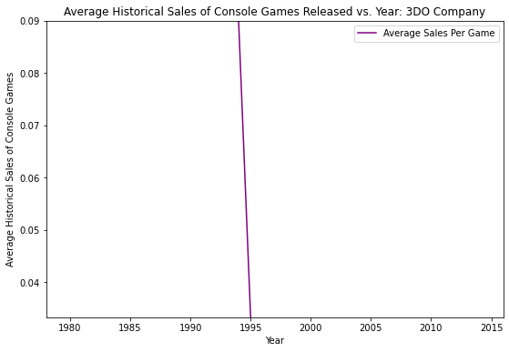

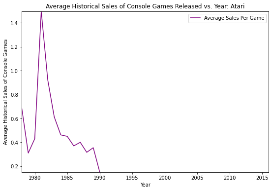

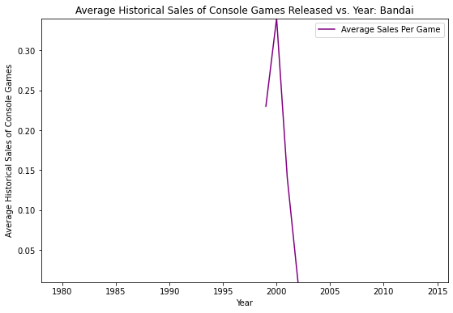

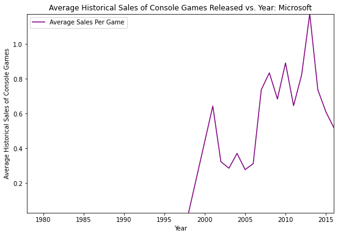

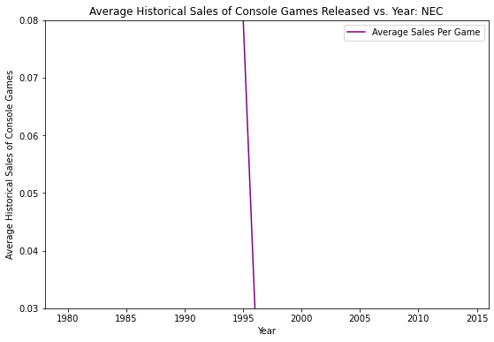

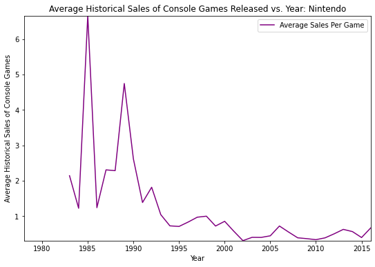

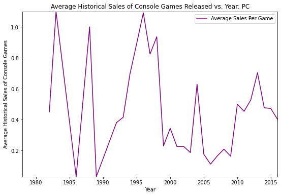

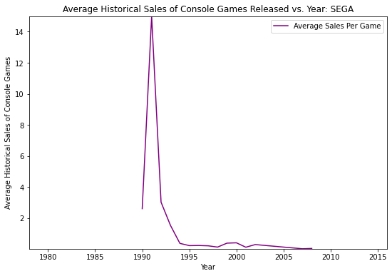

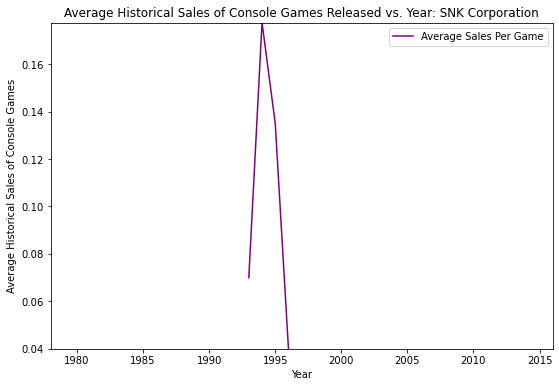

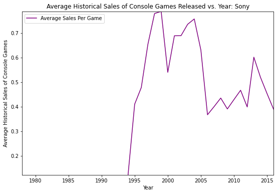

```python
# for each console developer, create a graph of average game sales per year
for label, group in df2.groupby(['Console Developer']):

    # create new dataframe to help plot sales
    consoleDF = pd.DataFrame(columns = ['Average Sales Per Game', 'Year'])

    # add row of each year's average game sales into dataframe
    for k, g in group.groupby(['Year']):
        totalSales = g['Total_Shipped'].sum()
        row = {'Average Sales Per Game': totalSales / len(g), 'Year': k}
        consoleDF = consoleDF.append(row, ignore_index = True)

    # plot dataframe
    ax2 = consoleDF.plot.line(x='Year', y='Average Sales Per Game', c='Purple', figsize=(9,6))
    plt.xlim([1978, 2016])
    plt.ylabel("Average Historical Sales of Console Games")
    plt.xlabel("Year")
    plt.title('Average Historical Sales of Console Games Released vs. Year: ' + str(label))
```

Now that we have these graphs, how do these companies compare against each other when it comes to average sales? This can be visualized by graphing the average historical sales of these companies on the same figure. However, we want to focus on companies that had games released on their consoles for more than five years, which narrows down the companies to Atari, Microsoft, Nintendo, PC, SEGA, and Sony. Additionally, since there seems to be a significant difference in sales and console company lifetime between the years before 1993 and after, two graphs of these time periods will be created for better visualization.

```python
# return dictionary of year and dataframe's corresponding yearly average sale per game
def salesavg(df, early):
    savg = dict()

    for yr, g in df.groupby(['Year']):

        # determine time period to include into dictionary
        if early:
            if yr < 1994:
                savg[yr] = g['Total_Shipped'].sum()/len(g)
        else:
            if yr > 1993:
                savg[yr] = g['Total_Shipped'].sum()/len(g)
    return savg
```

```python
condev = df2.groupby("Console Developer")

atari = condev.get_group("Atari")
msoft = condev.get_group("Microsoft")
nendo = condev.get_group("Nintendo")
pc = condev.get_group("PC")
sega = condev.get_group("SEGA")
sony = condev.get_group("Sony")
```

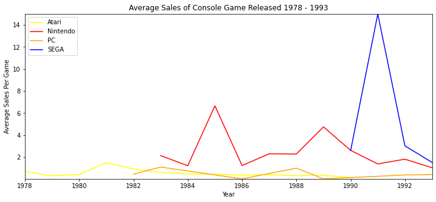

```python
# plot average sales per console game from 1978 to 1993
fig, ax = plt.subplots()
ax.plot(*zip(*salesavg(atari, True).items()), c = "yellow", label = "Atari")
ax.plot(*zip(*salesavg(msoft, True).items()), c = "purple", label = "Microsoft")
ax.plot(*zip(*salesavg(nendo, True).items()), c = "red", label = "Nintendo")
ax.plot(*zip(*salesavg(pc, True).items()), c = "orange", label = "PC")
ax.plot(*zip(*salesavg(sega, True).items()), c = "blue", label = "SEGA")
ax.plot(*zip(*salesavg(sony, True).items()), c = "black", label = "Sony")

plt.legend()
plt.xlabel("Year")
plt.ylabel("Average Sales Per Game")
plt.title("Average Sales of Console Game Released 1978 - 1993")
plt.show()
```

[figure not shown]

```python
# plot average sales per console game from 1994 to 2016
fig1, ax1 = plt.subplots()
ax1.plot(*zip(*salesavg(atari, False).items()), c = "yellow", label = "Atari")
ax1.plot(*zip(*salesavg(msoft, False).items()), c = "purple", label = "Microsoft")
ax1.plot(*zip(*salesavg(nendo, False).items()), c = "red", label = "Nintendo")
ax1.plot(*zip(*salesavg(pc, False).items()), c = "orange", label = "PC")
ax1.plot(*zip(*salesavg(sega, False).items()), c = "blue", label = "SEGA")
ax1.plot(*zip(*salesavg(sony, False).items()), c = "black", label = "Sony")

plt.legend(loc="lower right")
plt.xlabel("Year")
plt.ylabel("Average Sales Per Game")
plt.title("Average Sales of Console Game Released 1978 - 1993")
plt.show()
```

From 1994 to 2016, games had stopped releasing on Atari consoles, while new consoles from Microsoft and Sony were developed. Additionally, in this time period the numbers of average sales per console game dropped, with the majority of console companies performing about the same as other companies in terms of sales. The exceptions to this are SEGA, which had lower sales per console game compared to the others on average before discontinuing releases around 2008, and Microsoft, which started to outperform the other companies around 2007 - 2015. Another point of interest is 2016, where Nintendo seems to climb in average sales while the others decline. However, nothing conclusive can be stated as further information beyond 2016 is lacking.

This data shows that in the past decade, Microsoft, Nintendo, Sony, and the PC are the major consoles in game releases. These console developers perform similarly with one another in terms of the sales made from the games released on each company's consoles, with Microsoft having the highest average sales. However, the last year noted on the graph shows the uncertainty of whether these trends continue on after 2016. How will the gaming industry grow from there, and which companies will take the lead in its growth?

## Hypothesis Testing and Machine Learning

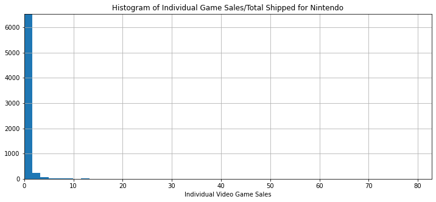

```python
fig, ax1 = plt.subplots(nrows=1, ncols=1, sharex=False, sharey=False, figsize=(12,5))
df_nin.hist(column = 'Total_Shipped', ax=ax1, bins = 50)
plt.title('Histogram of Individual Game Sales/Total Shipped for Nintendo')
plt.xlabel('Individual Video Game Sales')
plt.show()
```

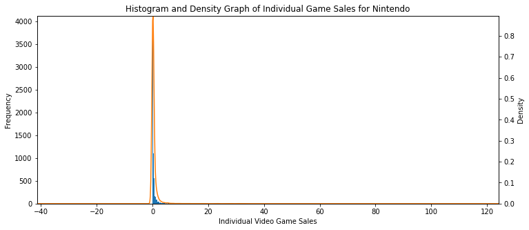

```python
fig, ax1 = plt.subplots(nrows=1, ncols=1, sharex=False, sharey=False, figsize=(12,5))
df_nin.hist(column = 'Total_Shipped', range = (0,10), ax=ax1, bins = 50)
ax2 = df_nin.Total_Shipped.plot(kind='kde', ax=ax1, secondary_y=True)
ax1.set_title('Histogram and Density Graph of Individual Game Sales for Nintendo')
ax1.set_ylabel('Frequency')
ax2.set_ylabel('Density')
ax1.set_xlabel('Individual Video Game Sales')
plt.rcParams['axes.xmargin'] = 0
plt.show()
```

It's worth noting with the histogram/density graphs above that it would be difficult to perform much meaningful analysis of individual video game titles with all of this data; this is why we decided to analyze Console Developer companies as a collective whole. Just by plotting a histogram with an associated distribution density for the video game entries belonging to Nintendo consoles, we can see that the frequency of total copies shipped (# of sales) results in an extremely narrow-centered histogram around 0 (90% or more of the data is compacted in that range of around 0-0.5 million copies sold). However, some histogram bars beyond 10 million copies sold can't even be seen because the number of video games that have reached that number of copies sold is extremely small (a look at the original dataframe ranked by sales will show that the total number of video game entries in the entire dataset that surpassed 10 million copies shipped is less than a hundred games). This observation is logical/reasonable; there are a lot of games released every year, and many of them are not successful. Even surpassing 1 million copies is a very, very admirable milestone for game developers. But, with so many games that do not have many copies sold regardless of their year of release, we thought it wouldn't be as interesting to perform an analysis on individual game titles.

```python
games.iloc[100:120]
```

|  | Name | Genre | Year | Total_Shipped | ESRB_Rating | Platform | Publisher | Developer | Critic_Score | User_Score | Console Developer |
| --- | --- | --- | --- | --- | --- | --- | --- | --- | --- | --- | --- |
| 100 | Mario Kart 8 | Racing | 2014 | 8.42 | E | WiiU | Nintendo | Nintendo | 8.8 | NaN | Nintendo |
| 101 | Tekken 3 | Fighting | 1998 | 8.30 | T | PS | Namco | Namco | 9.6 | NaN | Sony |
| 102 | FIFA 16 | Sports | 2015 | 8.22 | E | PS4 | EA Sports | EA Canada | 8.5 | NaN | Sony |
| 103 | GoldenEye 007 | Shooter | 1997 | 8.09 | T | N64 | Nintendo | Rare Ltd. | 9.8 | NaN | Nintendo |
| 104 | Star Wars Battlefront (2015) | Shooter | 2015 | 8.03 | T | PS4 | Electronic Arts | EA DICE | 7.1 | NaN | Sony |
| 105 | FIFA 13 | Sports | 2012 | 8.01 | E | PS3 | EA Sports | EA Canada | NaN | NaN | Sony |
| 106 | Halo 2 | Shooter | 2004 | 8.00 | M | XB | Microsoft Game Studios | Bungie Studios | 9.6 | NaN | Microsoft |
| 107 | The Sims 3 | Simulation | 2009 | 7.96 | T | PC | Electronic Arts | EA Redwood Shores | 8.5 | NaN | PC |
| 108 | Grand Theft Auto: Liberty City Stories | Action | 2005 | 7.72 | M | PSP | Rockstar Games | Rockstar Leeds | 8.8 | NaN | Sony |
| 109 | Pac-Man | Puzzle | 1982 | 7.70 | NaN | 2600 | Atari | Atari | NaN | NaN | Atari |
| 110 | Pokemon Platinum Version | Role-Playing | 2009 | 7.60 | E | DS | Nintendo | Game Freak | 8.3 | 8.9 | Nintendo |
| 111 | The Legend of Zelda: Ocarina of Time | Adventure | 1998 | 7.60 | E | N64 | Nintendo | Nintendo EAD | 9.9 | 10.0 | Nintendo |
| 112 | Crash Bandicoot 2: Cortex Strikes Back | Platform | 1997 | 7.58 | E | PS | Sony Computer Entertainment | Naughty Dog | 8.6 | NaN | Sony |
| 113 | Call of Duty: Advanced Warfare | Shooter | 2014 | 7.53 | M | PS4 | Activision | Sledgehammer Games | 8.5 | NaN | Sony |
| 114 | Call of Duty: World at War | Shooter | 2008 | 7.50 | M | X360 | Activision | Treyarch | 8.5 | 7.8 | Microsoft |
| 115 | Super Mario Bros. 2 | Platform | 1988 | 7.46 | NaN | NES | Nintendo | Nintendo EAD | NaN | NaN | Nintendo |
| 116 | Super Mario Galaxy 2 | Platform | 2010 | 7.41 | E | Wii | Nintendo | Nintendo EAD Tokyo | 9.7 | 9.8 | Nintendo |
| 117 | Super Smash Bros. Melee | Fighting | 2001 | 7.41 | T | GC | Nintendo | HAL Laboratory | 9.2 | NaN | Nintendo |
| 118 | Call of Duty: Black Ops 3 | Shooter | 2015 | 7.37 | M | XOne | Activision | Treyarch | NaN | NaN | Microsoft |
| 119 | Battlefield 3 | Shooter | 2011 | 7.35 | M | X360 | Electronic Arts | Dice | 8.5 | NaN | Microsoft |

Instead, we're again interested in how these major "Console Developer Companies" have been doing in terms of the total game sales year to year on the platforms they own (admittedly, PC is more a general platform than a company itself; we're sure Microsoft takes some of the profit from Windows operating system games but it is not measurable from our data). Although it would be nice to perform Time Series modeling, our data unfortunately is not at enough regular intervals (would probably have to be monthly) for us to see a proper Time Series forecast in action. Instead, we'll use the sklearn module to inform us of a polynomial regression curve that best fits the total sales data for each "company". First, we'll need to properly organize our data into different dataframes grouped by Console Developer, and then store only the necessary columns of total sales for each year.

```python
# Create four different dataframes for each of the console developer companies or major platforms;
# They are each grouped so that only the applicable rows are contained in their dataframes.
df_nin = df2[df2['Console Developer'] == 'Nintendo']
df_mic = df2[df2['Console Developer'] == 'Microsoft']
df_sony = df2[df2['Console Developer'] == 'Sony']
df_pc = df2[df2['Console Developer'] == 'PC']
# Also create a separate dataframe that we'll use to keep track of a unique year with the total sales
# for video games that ran on platforms owned by the console developer company
salesNin = pd.DataFrame(columns = ['Total Sales', 'Year'])
salesMic = pd.DataFrame(columns = ['Total Sales', 'Year'])
salesSony = pd.DataFrame(columns = ['Total Sales', 'Year'])
salesPC = pd.DataFrame(columns = ['Total Sales', 'Year'])

# For each dataframe, we group by year and then we take the sum of its total shipped copies.
# Next, we append it as a new row into the other separate dataframe, which is what we will use to easily graph
for k, g in df_nin.groupby(['Year']):
    totalSales = g['Total_Shipped'].sum()
    row = {'Total Sales': totalSales, 'Year': k}
    salesNin = salesNin.append(row, ignore_index = True)
for k, g in df_mic.groupby(['Year']):
    totalSales = g['Total_Shipped'].sum()
    row = {'Total Sales': totalSales, 'Year': k}
    salesMic = salesMic.append(row, ignore_index = True)
for k, g in df_sony.groupby(['Year']):
    totalSales = g['Total_Shipped'].sum()
    row = {'Total Sales': totalSales, 'Year': k}
    salesSony = salesSony.append(row, ignore_index = True)
for k, g in df_pc.groupby(['Year']):
    totalSales = g['Total_Shipped'].sum()
    row = {'Total Sales': totalSales, 'Year': k}
    salesPC = salesPC.append(row, ignore_index = True)
```

At this stage, we can begin to fit a polynomial regression model to see the video games sales of different console companies over time (ex: sales for video games for Microsoft released from its start in 1998 year by year until Microsoft video games released in 2016). It should be fairly clear from the graphs of sales above that there isn't a nice linear model that would fit the data. But, if our regression fit should be polynomial, how do we determine which degree is appropriate? We could easily underfit the data by using a linear regression (degree = 1), but using a 10th degree-order polynomial would probably be an overfit. The last thing we want to do is to create a model that perfectly fits our data, but would probably be less accurate for a future test set. Given the lack of availability of long-term data (we don't have many years), we decided to use the entire data available as the training set and the test set. This means that we're making a best fit for all of our data, but then comparing our data to itself to determine the accuracy of our model. Still, our first order of business is to determine the correct polynomial fit for each console developer company.

```python
def polydeg(df, name):
    # We're keeping track of the degree, linear_score, and RMSE (root mean squred error) for each degree as we
    # upwardly increase to see how the fit looks
    linear_sample_score = []
    poly_degree = []
    rmse = []
    # For each degree, 1 to 6 (7 is excluded in Python range function)
    for degree in range(1, 7):
        # We create a polynomial regression with PolynomialFeatures module in sklearn
        poly_reg = PolynomialFeatures(degree)
         # I pass in the year column as the "x-values" of the data we're trying to fit
        # poly_reg.fit creates different feature coefficients with the appropriate order so we
        # need to transform our array accordingly
        X_poly = poly_reg.fit_transform(np.array(df['Year']).reshape(-1, 1))
        # Create a new LinearRegression object from sklearn's Linear Regression module
        lin_reg = LinearRegression()
        # Reshaping the Total Sales column as a new array so that we can fit on it as the "y-values"
        y_reshape = np.array(df['Total Sales']).reshape(-1, 1);
        # Find the linear regression fit with our X_poly variable (x-values reshaped into two-dimensional array)
        # as well as our y-reshaped values
        lin_reg.fit(X_poly, y_reshape)
        y_pred = lin_reg.predict(X_poly)
        test_pred = np.array(y_pred)
        # RMSE is the Root Mean Square Error that helps us measure how spread out our residuals are.
        # It's the square of the difference between our y-predicted value and our y-actual value, summed together
        # and divided by the number of values, and then rooted.
        RMSE=np.sqrt(np.sum(np.square(test_pred-y_reshape)))
        # Append our r^2 score to a list for later use
        linear_sample_score.append(r2_score(np.array(df['Total Sales']), y_pred))
        # Append to RMSE list for later use
        rmse.append(RMSE)
        # Append to polynomial degree array for later use
        poly_degree.append(degree)
        # The plot below shows what the predicted values vs. actual values look like with our
        # polynomial regression fits for polynomials of different degrees
        # Any points that fall on the red line or close to it mean that the predicted and actual values were
        # extremely close to each other for that year's data point
        plt.figure()
        plt.title("Predicted vs. actual for polynomial of degree {} : {}".format(degree, name),fontsize=15)
        plt.xlabel("Actual values")
        plt.ylabel("Predicted values")
        plt.scatter(y_reshape,test_pred)
        plt.plot(y_reshape,y_reshape,'r',lw=2)

    plt.figure(figsize=(8,5))
    plt.grid(True)
    # Plot the RMSE(y-variable) vs. polynomial degree(x-variable) with the arrays we stored above
    plt.plot(poly_degree,rmse,lw=3,c='red')
    plt.title("RMSE vs. Model complexity",fontsize=20)
    plt.xlabel ("\nDegree of polynomial",fontsize=20)
    plt.ylabel ("RMSE",fontsize=15)

    plt.figure(figsize=(8,5))
    plt.grid(True)
    # Plot the R^2 score(y-variable) vs. polynomial degree(x-variable) with the arrays we stored above
    plt.plot(poly_degree,linear_sample_score,lw=3,c='red')
    plt.title("R^2 score vs. Model complexity\n",fontsize=20)
    plt.xlabel ("\nModel Complexity: Degree of polynomial",fontsize=20)
    plt.ylabel ("R^2 score",fontsize=15)
```

### Nintendo

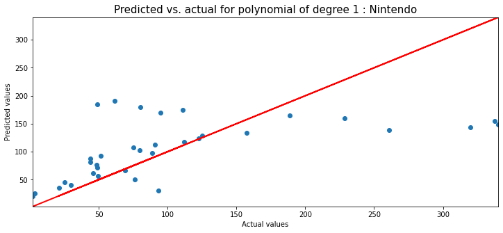

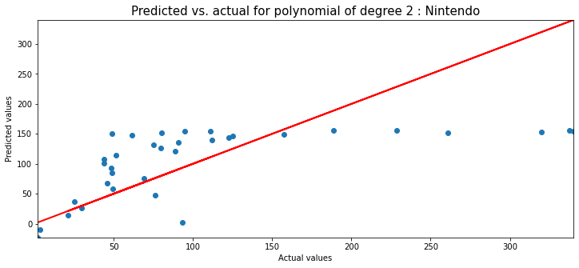

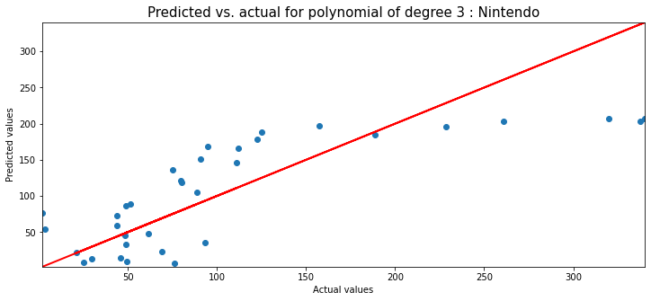

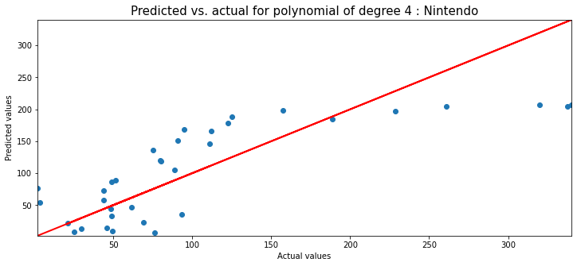

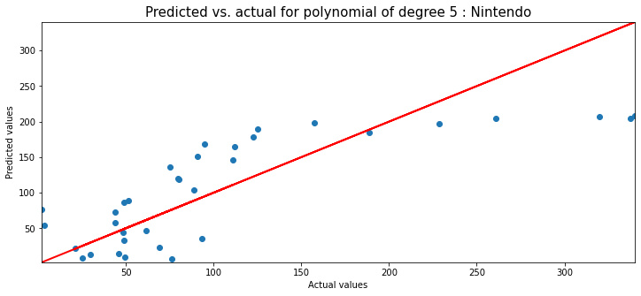

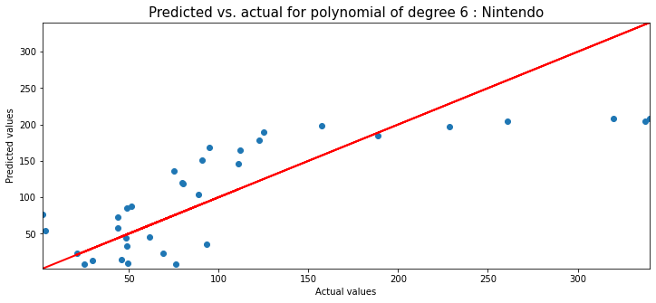

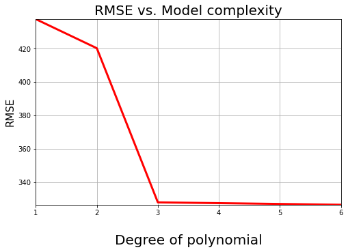

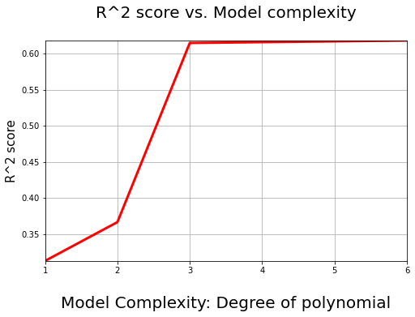

```python
polydeg(salesNin, "Nintendo")
```

We can think of the first few graphs (labeled Predicted vs. actual for polynomial of degree {n}) as an initial look as to the difference between predicted and actual values for polynomial regression fits with different degrees. However, it doesn't concretely tell us which polynomial degree order is the appropriate one to use. The graphs below will allow us to see which polynomial degree effectively minimizes the RMSE (similar to a gradient descent function). A smaller RMSE means that the residuals are smaller and thus, the polynomial is a better fit. Of course, then, a higher polynomial fit should be result in a smaller RMSE (so it'll keep decreasing as we increase the order). By graphing the change in RMSE below for each degree, we can see which degree significantly drops the RMSE, and then from that point on, future degrees don't have a significant drop. This will allow us to select a polynomial degree that doesn't overfit the data, because we can stop at the degree that effectively minimizes the RMSE to the point where higher degrees don't do minimize the RMSE by that much more.

In this case, we can see for Nintendo, the best degree of polynomial for regression fit is suggested to be 3 (a cubic function). After 3, the RMSE does not drop by that much more, so anything greater than 3 could probably be considered an overfit.

The R^2 score, or the coefficient of determination, is another way in which we can statistically measure how close our data is to the regression line. To be more accurate, it is the proportion of the variance for our sales that's explained by the year in our regression model polynomially. We can see that our R^2 score below might not be that great (60-ish% for Nintendo), but what the graph also shows is that the R^2 score does not significantly increase after the 3rd degree either. So again, anything past the 3rd degree is not effective or necessary, and would probably be considered an overfit.

### Microsoft

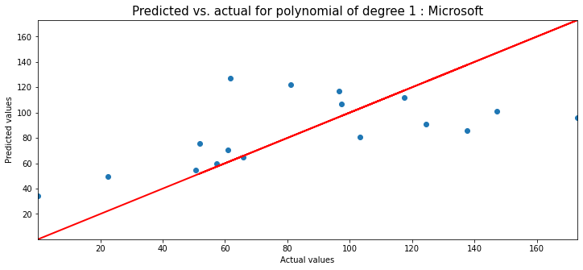

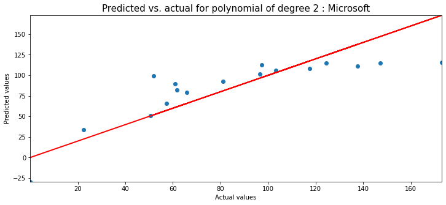

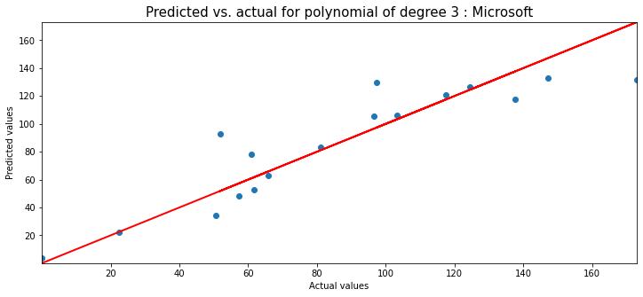

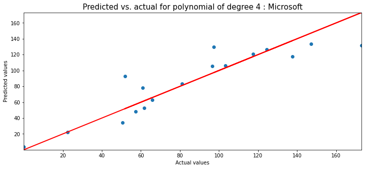

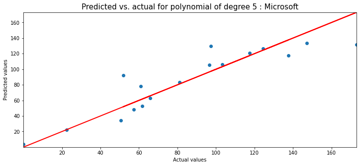

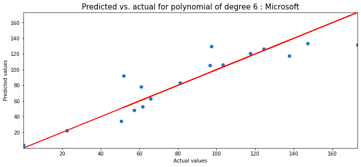

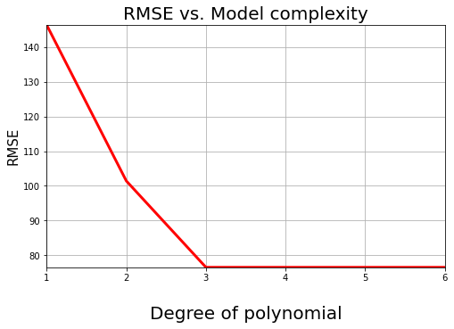

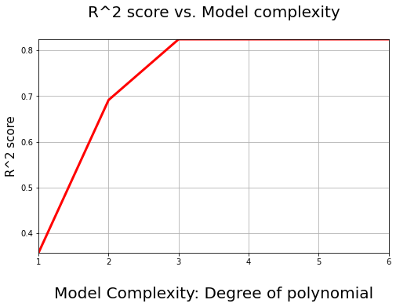

```python
polydeg(salesMic, "Microsoft")
```

[figure not shown]

```python
plt.figure(figsize=(8,5))
plt.grid(True)
plt.plot(poly_degree,rmse,lw=3,c='red')
plt.title("Model complexity (highest polynomial degree) vs. test score\n",fontsize=20)
plt.xlabel ("\nDegree of polynomial",fontsize=20)
plt.ylabel ("Root-mean-square error on test set",fontsize=15)
```

The graphs for Microsoft suggest that the the best degree of polynomial for regression fit is 3 as well (a cubic function). After 3, the RMSE does not drop by that much more, so anything greater than 3 could probably be considered an overfit. It's possible depending on the margin of error that we could use a quadratic function of degree 2 based on the graphs, but as there seems to be a visible jump in our RMSE score from 2 to 3, we thought 3 would be a safer bet.

### Sony

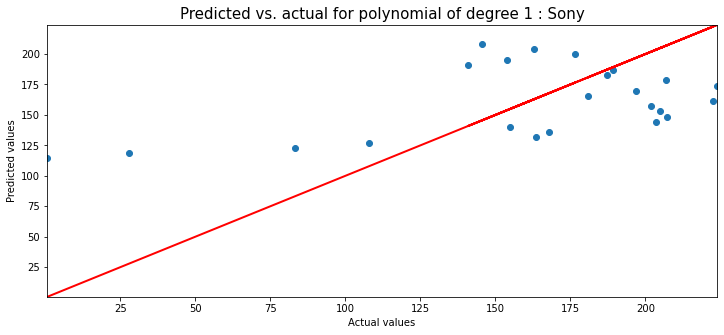

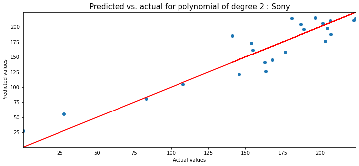

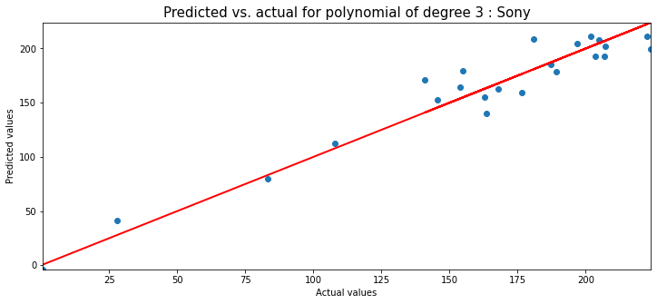

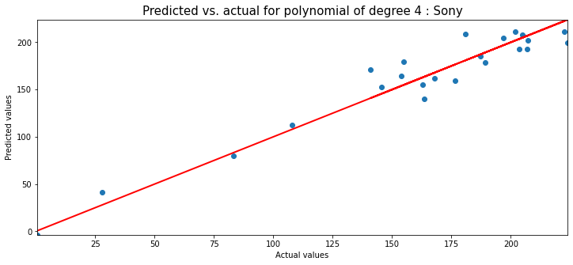

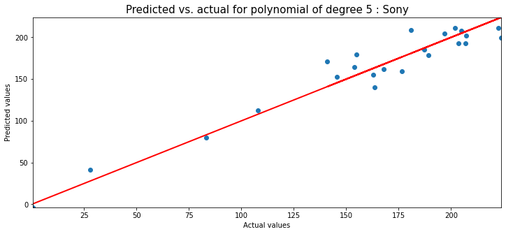

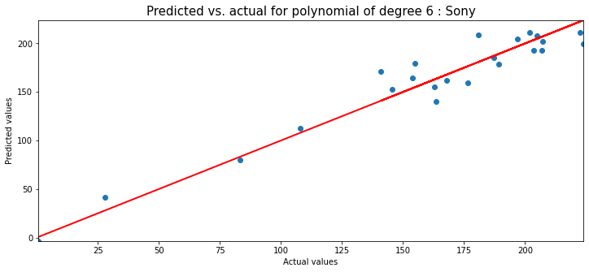

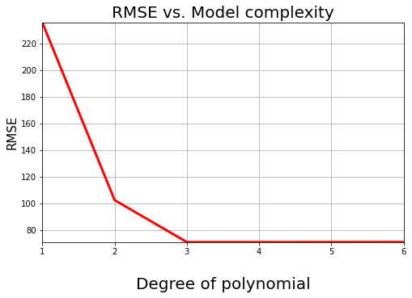

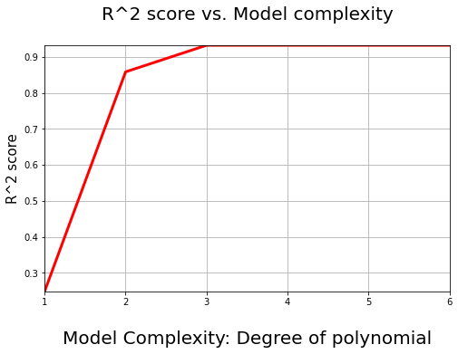

```python
polydeg(salesSony, "Sony")
```

Similar to Microsoft, the graphs for Sony suggest that the the best degree of polynomial for regression fit is 3 as well (a cubic function). After 3, the RMSE does not drop by that much more (and the R^2 score does not increase significantly by that much more), so anything greater than 3 would probably be considered an overfit. The R^2 score also appears to be pretty nice; the percentage of variance in total sales in a year that can be explained by the year itself is higher than 90%.

### PC

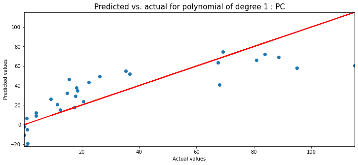

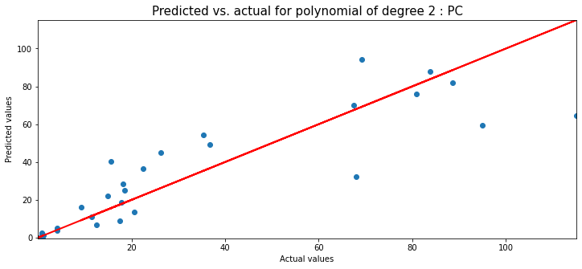

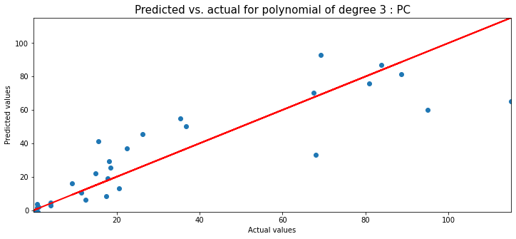

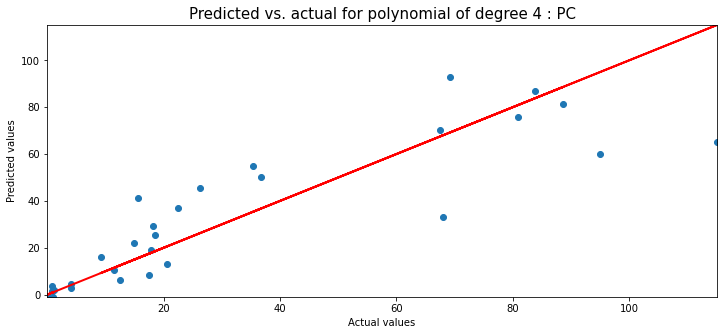

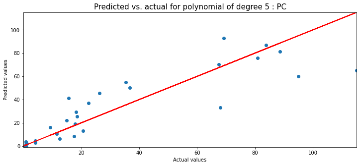

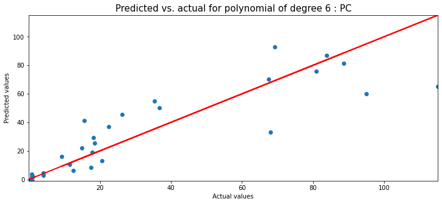

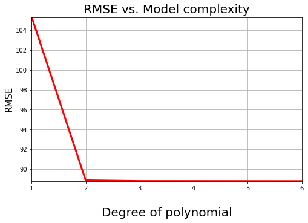

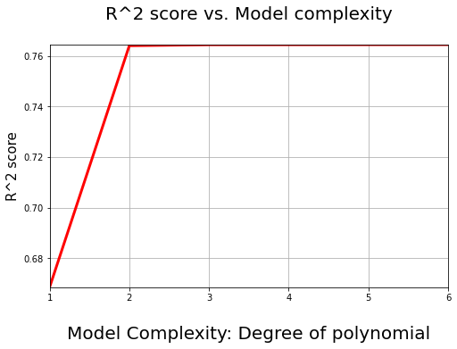

```python
polydeg(salesPC, "PC")
```

Interestingly enough, the graphs for PC suggest that the the best degree of polynomial for regression fit is 2 (a quadratic function). After 2, the RMSE does not drop by that much more (and the R^2 score does not increase significantly by that much more), so anything greater than 2 would probably be considered an overfit.

## Final Polynomial Regression Fit Models

Now that we have the ideal degree of order for polynomial regression line for each console developer company, we can plot the actual regression fit and see how it looks, while also predicting values to, say, 2020. It'll be interesting to see what our models suggest. Do our models suggest that Nintendo is on the uptrend? Is PC gaming a viable central platform for gaming in the years to come?

```python
def regfit(df, deg, name):
    # First create a scatterplot of the actual values
    # plot total sales data with regression fit, predict future sales values
    fig, ax = plt.subplots()
    ax.scatter(df["Year"], df["Total Sales"])
    # Now we use PolynomialFeatures to again find a regression line,
    # but this time we know the degree of the polynomial regression should be for example, 3 for Nintendo
    poly_reg = PolynomialFeatures(degree=deg)
    X_poly = poly_reg.fit_transform(np.array(df['Year']).reshape(-1, 1))
    lin_reg = LinearRegression()
    lin_reg.fit(X_poly, np.array(df['Total Sales']).reshape(-1, 1))
    y_pred = lin_reg.predict(X_poly)
    plt.plot(df['Year'], y_pred, c='red')
    plt.title('Polynomial Regression Fit for ' + name)
    plt.xlabel('Year')
    plt.ylabel('Total Sales of Games Released in Year')

    print(name + ':')
    print('2016 Predicted Value: ' + str(lin_reg.predict(poly_reg.fit_transform([[2016]]))))
    print('2017 Predicted Value: ' + str(lin_reg.predict(poly_reg.fit_transform([[2017]]))))
    print('2018 Predicted Value: ' + str(lin_reg.predict(poly_reg.fit_transform([[2018]]))))
    print('2019 Predicted Value: ' + str(lin_reg.predict(poly_reg.fit_transform([[2019]]))))
    print('2020 Predicted Value: ' + str(lin_reg.predict(poly_reg.fit_transform([[2020]]))))
```

```
Nintendo:
2016 Predicted Value: [[47.36385065]]
2017 Predicted Value: [[1.81028444]]
2018 Predicted Value: [[-50.64715952]]
2019 Predicted Value: [[-110.37509316]]
2020 Predicted Value: [[-177.74012893]]
```

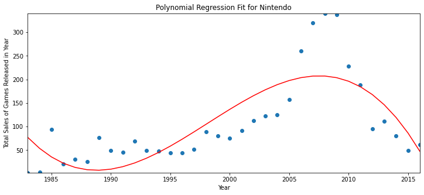

```python
regfit(salesNin, 3, "Nintendo")
```

```
Microsoft:
2016 Predicted Value: [[52.86237717]]
2017 Predicted Value: [[14.21126223]]
2018 Predicted Value: [[-33.67341089]]
2019 Predicted Value: [[-91.52353096]]
2020 Predicted Value: [[-160.07099104]]
```

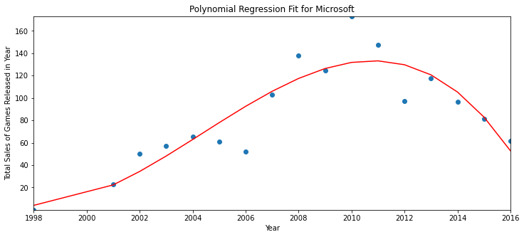

```python
regfit(salesMic, 3, "Microsoft")
```

```
Sony:
2016 Predicted Value: [[152.68306494]]
2017 Predicted Value: [[152.60068083]]
2018 Predicted Value: [[155.15416217]]
2019 Predicted Value: [[160.75120711]]
2020 Predicted Value: [[169.79951429]]
```

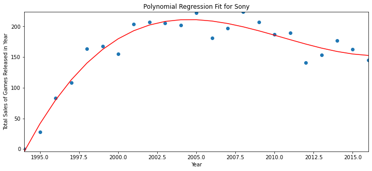

```python
regfit(salesSony, 3, "Sony")
```

```
PC:
2016 Predicted Value: [[94.32594809]]
2017 Predicted Value: [[100.93833048]]
2018 Predicted Value: [[107.77373154]]
2019 Predicted Value: [[114.83215125]]
2020 Predicted Value: [[122.11358963]]
```

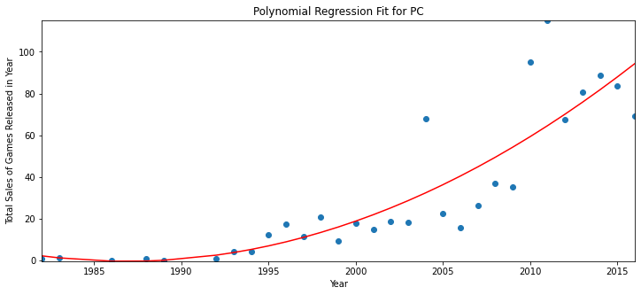

```python
regfit(salesPC, 2, "PC")
```

## Final Observations and Reflections

However, more reliable data would need to be acquired about the past four years to see how well our regression fits predicted the average sales of these game console developers. With the releases of the Nintendo Switch, PS5, and Xbox Series X and S in the past four years, it is possible that the trendlines of average sales for these game console companies will alter with the addition of a more recent dataset - for better or for worse. Looking back at our efforts to find patterns in our data, our results were shocking regarding predictions for video game sales for future years, but finding shocking or contradictory results to what we believe is okay! In the hopes of pursuing more accurate results or confirming the trends that were found in our project, we would need to perform further testing and analysis (and probably with self-scraped data from a website that has even more information about a game's sales from month to month, and updates sales more immediately) is preferable; this is something to surely explore down the road. Until then, keep on data scraping, exploring patterns in your data, and testing hypotheses, all while gaming in between!